# Bayesian sparse regression with missing data imputation in Stan

Guido Biele

04 September 2018

This is a quick description of applying a Bayesian version of sparse regression for a prediction task. This model uses Stan via RStan to implement the regression because I prefer Bayesian inference (not everyone might agree here) and, more importantly, because it allows to do imputation of missing data and estimation parameters for the prediction model on one go.

The prediction task is to predict [ferritin](https://en.wikipedia.org/wiki/Ferritin) levels measured in biological samples with questionnaire data from [MoBa](https://www.fhi.no/en/studies/moba/).

[Here](https://github.com/stan-dev/rstan/wiki/RStan-Getting-Started) is the getting started information for RStan,the R-interface to Stan.

## Data preparation

As often, this step involves lots of work to get the data in a format that is useful for prediciton.

We start by doing some data cleaning. I just set a few values which are much different than other values for a variable to NA.

```r
load("mydata_iron.Rdata")

mydata$menstrualCycleLength[mydata$menstrualCycleLength < 21 | mydata$menstrualCycleLength > 35 ] = NA
mydata$d_iron[mydata$d_iron == 0] = NA
mydata$Hb_drop[mydata$Hb_drop > 5] = NA
mydata$Hb_low[mydata$Hb_low > 20] = NA
mydata$Hb_low[mydata$Hb_low < 6] = NA
mydata$Hb_low_wk[mydata$Hb_low_wk > 27] = NA   # left skewd variable
mydata$Hb_current_wk[mydata$Hb_current_wk > 36] = NA  # left skewd variable
mydata$Hb_high[mydata$Hb_high > 20] = NA
mydata$Hb_current[mydata$Hb_current > 20] = NA
mydata$Hb_current[mydata$Hb_current < 6] = NA
mydata$blood_sampling_week[mydata$blood_sampling_week > 28] = NA
mydata$s_hemeiron_dose[mydata$s_hemeiron_dose > 10] = NA
mydata$tea_herbal[mydata$tea_herbal > 1000] = NA
mydata$tea_black[mydata$tea_black > 1000] = NA
mydata$milk[mydata$milk > 2200] = NA
mydata$crp[mydata$crp > 100] = NA
mydata$interpregnancy_interval[is.na(mydata$interpregnancy_interval)] = 0
mydata$multiple_pregancies = 1
mydata$multiple_pregancies[mydata$interpregnancy_interval == 0] = 0

mydata$OC_duration = ordered(mydata$OC_duration)
mydata$OC_recency = ordered(mydata$OC_recency)
mydata$period_regular = ordered(mydata$period_regular)

mydata$ironSupplement_single = factor(mydata$ironSupplement_single)
# now a few transformations to prepare log transforms
mydata$OC_firstuse = mydata$OC_firstuse - min(mydata$OC_firstuse,na.rm = T)+1
mydata$ppBMI = mydata$ppBMI - min(mydata$ppBMI,na.rm = T)+1
```

Now lets flip left-skewed variables. This means we can use log transforms to make them more normally distributed.

```r
vars = grep("PREG|year",
               names(mydata),
               value = T,
               invert = T)
numvars = names(which(do.call(c,lapply(mydata[,vars], function(x) class(x)[1])) == "numeric"))

# flip left skewed variables
left_skewed = names(which(apply(mydata[,numvars],2,skewness, na.rm = T) < -.7))
for (v in left_skewed) {
  mydata[,v] = abs(mydata[,v]-max(mydata[,v],na.rm = T)) + min(mydata[,v],na.rm = T)
  mydata[,v] = mydata[,v] - min(mydata[,v],na.rm = T)
}
```

Next we do log transformations for selected variables to get rid of the right-skewed values. We are also plotting histograms before and after transformation for the variables we transform.

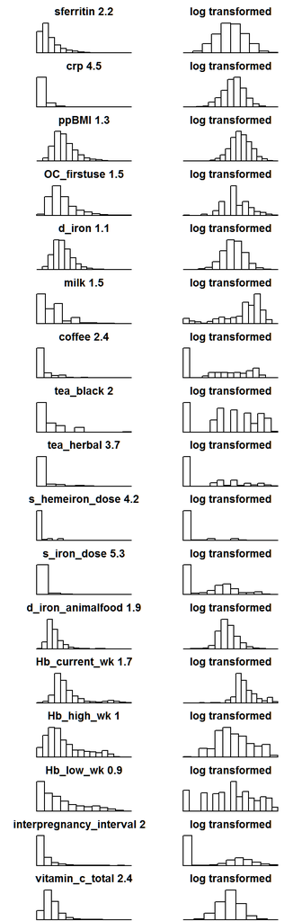

```r
skewed_numvars = names(which(apply(mydata[,numvars],2,skewness, na.rm = T) > .7))
mytdata = mydata
par(mar=c(0,3,2,1), mgp=c(2,.7,0), tck=-.01)
par(mfrow = c(17,2))
is_zero_inflated = c()
is_skewed = c()
for (v in skewed_numvars) {
  x = mydata[,v]
  if (mean(x == 0,na.rm = T) > .10)
    is_zero_inflated = c(is_zero_inflated,
                         v)
  if(skewness(x[x>0], na.rm = T) > .7) {
    is_skewed = c(is_skewed,v)
    hist(x,
         main = paste(v,round(skewness(x,na.rm = T),digits = 1)),
         xlab = "",
         xaxt = "n",
         ylab = "",
         yaxt = "n")
    if (min(x,na.rm = T) == 0) {
      x = x+1
    }
    mytdata[,v] = log(x)
    hist(log(x),xlab = "",
         main = "log transformed",
         xaxt = "n",
         ylab = "",
         yaxt = "n")
  }
}
```

Now lets have a first look at the correlation matrix.

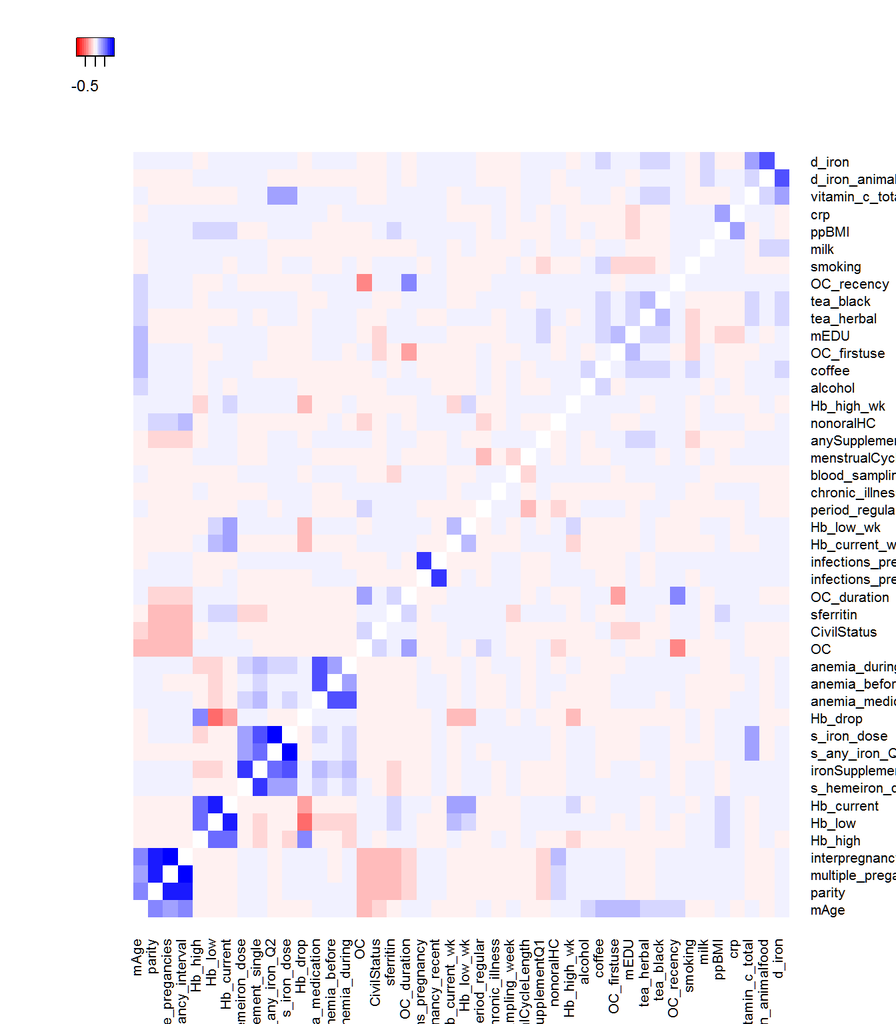

```r
nmat = matrix(NA, ncol = length(vars), nrow = nrow(mydata))
colnames(nmat) = vars
for (v in vars) {
  if (is.numeric(mydata[,v])) {
    nmat[,v] = mytdata[,v]
  } else {
    nmat[,v] = as.numeric(mytdata[,v])
  }
}

cm = cor(nmat, use = "pairwise.complete.obs")
diag(cm) = NA
heatmap.g = function(cm, key = T, margins = c(5,5)) {
  heatmap.2(cm,
          col = colorRampPalette(colors = c("red","white","blue")),
          breaks = 21,
          dendrogram = "none",
          key = key,
          key.title = "",
          density.info = "none",
          key.xlab = "",
          margins = margins,
          key.par = par(mar = c(1,0,0,0),
                        mgp=c(2,.2,0),
                        tck=-.01),
          keysize = .7,
          trace = "none")
}
heatmap.g(cm)
```

Lets focus on high correlations :

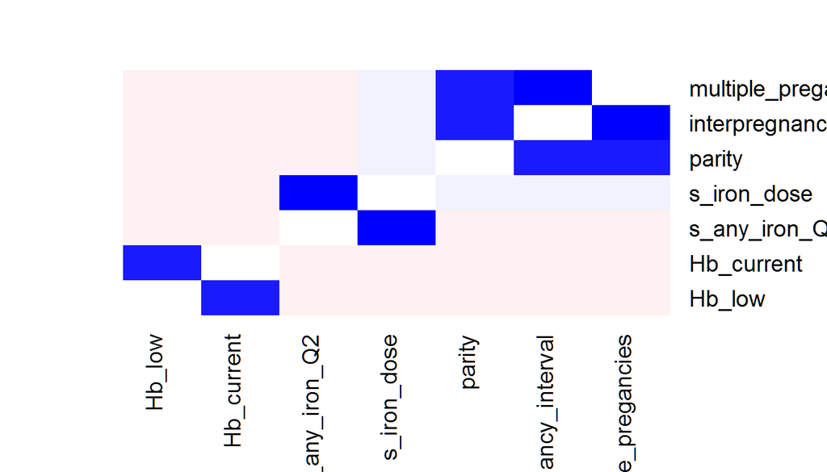

```r
large_cors = names(which(colSums(abs(cm) > .8,na.rm = T) > 0))
hcrs = cm[large_cors,large_cors]
heatmap.g(hcrs, key = F, margins = c(8,8))
```

So we have a few variables that seem redundant. We will deal with them by just removing them.

```r
remove_vars = c("multiple_pregancies","s_any_iron_Q2","Hb_low_wk","CivilStatus")
```

CivilStatus is just an inconvenient nominal variable that in my experience explains little in MoBa analyses, so I just remove it.

## Prepare standata

Now we prepare data for a model with automatic shrinkage. The special challenge here is that we want to use quadratic terms (and later maybe all pairwise interactions) while also imputing missing data. Hence, we have a somewhat elaborate procedure to pre-process the data and prepare the complete design matrix in the Stan model itself.

To reiterate: Outside Stan we only generate a design matrix with columns for each basic variable. Inside Stan we generate the quadratic (and interaction) terms once for all data and then at each iteration of the sampling process again for all imputed variables.

We start by scaling variables and saving scaling values. The matrix preX that is prepared below is the basic design matrix that includes all variables which will be log-transformed, scaled, and used to generate quadratic terms for numeric variables in Stan.

Let’s define different types of variables which will be treated differently.

```r
use_vars = setdiff(colnames(mydata),
                   c("sferritin","PREG_ID_2014","year",remove_vars))

use_vars = names(which(colSums(is.na(mydata[,use_vars])) < 400))
#mydata = mydata[sample(nrow(mydata),500),]
#use_vars = use_vars[sample(length(use_vars),10)]

y = log(mydata$sferritin)

preX = mydata[use_vars]
non_numeric_vars = names(which(sapply(preX[,use_vars],
                                      function(x) class(x)[1]) != "numeric"))
for (v in non_numeric_vars)
  preX[,v] = as.numeric(preX[,v])-1

binary_vars = names(which(apply(preX,2,
                                function(x) length(unique(x[!is.na(x)]))) == 2))
transform_vars = intersect(use_vars,skewed_numvars)
scale_vars = setdiff(use_vars,binary_vars)
scale_vars = c(scale_vars[!(scale_vars %in% transform_vars)],
               scale_vars[(scale_vars %in% transform_vars)])
zero_inflated_vars = intersect(use_vars,is_zero_inflated)
```

Now we put the basic design matrix, preX, together. This also includes derived binary variables. These are derived from numeric variables that are zero-inflated and have a $0$ where the numeric variable is zero and a 1 everywhere else.

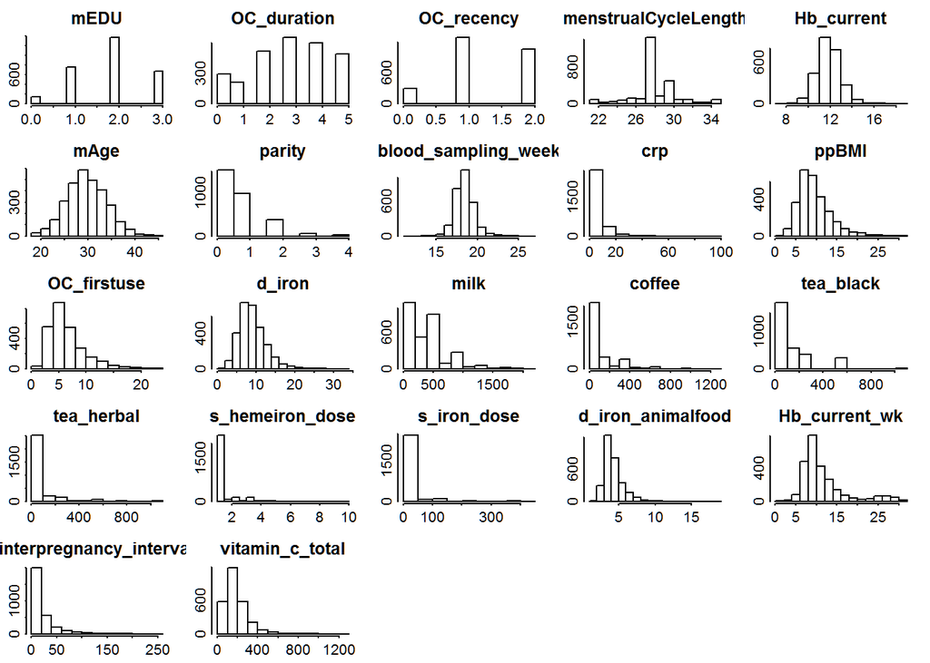

```r
preX = preX[,c(scale_vars,binary_vars)]

derived_binary = preX[,zero_inflated_vars]
derived_binary[derived_binary == 0 | is.na(derived_binary)] = 0
derived_binary = (derived_binary != 0)*1
colnames(derived_binary) = paste0(colnames(derived_binary),"_b")

zero_inflated_vars = colnames(derived_binary)

preX = cbind(preX,derived_binary)

use_vars = names(preX)

transf_idx = which(use_vars %in% transform_vars);
transf_range = range(transf_idx)

scale_sd = rep(NA,length(scale_vars))
scale_mu = rep(NA,length(scale_vars))
for (v in 1:length(scale_vars)) {
  if(scale_vars[v] %in% transform_vars) {
    mx = min(preX[,v],na.rm = T)
    if (mx == 0) {
      preX[,v] = preX[,v] + 1
    } else if (mx > 1) {
      preX[,v] = preX[,v] - mx + 1
    }
    scale_sd[v] = sd(log(preX[,v]),na.rm = T)
    scale_mu[v] = mean(log(preX[,v]),na.rm = T)
  } else {
    scale_sd[v] = sd(preX[,v],na.rm = T)
    scale_mu[v] = mean(preX[,v],na.rm = T)
  }
}

par(mfrow = c(5,5),
    mar=c(1.5,1.5,2,1), mgp=c(2,.2,0), tck=-.01)
hs = sapply(scale_vars,
            function(x) hist(preX[,x],main = x,ylab = ""))
```

### Pairwise interactions

Next we prepare all pairwise interactions and remove interactions of numeric variables with its derived binary variable.

```r
interactions = combn(1:ncol(preX),2)
rm_interactions = c()
for (v in zero_inflated_vars) {
  i1 = which(colnames(preX) == sub("_b$","",v))
  i2 = which(colnames(preX) == v)

  rm_interactions = c(rm_interactions,
                      c(which((interactions[1,] == i1) & (interactions[2,] == i2)),
                        which((interactions[1,] == i2) & (interactions[2,] == i1))))
}
interactions = interactions[,-rm_interactions]
```

To speed up the fitting, we remove interaction variables that have a low entropy or are highly correlated with other (non-interaction) variables. To do this, we first need to do the scaling that will later also be done in Stan here in R.

```r
## do log-transformations and scaling
N = nrow(preX)
M = ncol(preX) - length(zero_inflated_vars)
M_drv_bin = length(zero_inflated_vars)
MB = M + M_drv_bin
M_quadratic = length(scale_vars)
MBQ = MB + M_quadratic
N_interactions = ncol(interactions)
MBQI = MBQ + N_interactions

X_scaled = matrix(NA,nrow = N, ncol = MBQI)
X_scaled[,1:MB] = as.matrix(preX)


scale_mu = c(scale_mu, + rep(0,length(c(binary_vars,zero_inflated_vars,scale_vars))))
scale_sd = c(scale_sd, + rep(1,length(c(binary_vars,zero_inflated_vars,scale_vars))))


for (k in 1:M_quadratic) {
  X_scaled[is.na(X_scaled[,k]),k] = mean(preX[,k],na.rm = T)
  if (k >= transf_idx[1]) {
    X_scaled[,k][X_scaled[,k] == 0] = 1
    X_scaled[,k] = (log(X_scaled[,k])-scale_mu[k])/scale_sd[k]
  } else {
    X_scaled[,k] = (X_scaled[,k]-scale_mu[k])/scale_sd[k]
  }

  scale_sd[MB+k] = sd(X_scaled[!is.na(preX[,k]),k]^2,na.rm = T)
  scale_mu[MB+k] = mean(X_scaled[!is.na(preX[,k]),k]^2,na.rm = T)

  X_scaled[,MB+k] = ((X_scaled[,k]^2)-scale_mu[MB+k])/scale_sd[MB+k]
}

for (k in which(colSums(is.na(X_scaled[,1:MBQ]))>0)) {
  X_scaled[is.na(X_scaled[,k]),k] = 0
}

for (i in 1:N_interactions) {
  X_scaled[,MBQ + i ] = X_scaled[,interactions[1,i]] * X_scaled[,interactions[2,i]]
}
```

Now we remove interactions with low entropy, i.e. interaction terms where the large majority of participants (199 out of 200) have the same value .

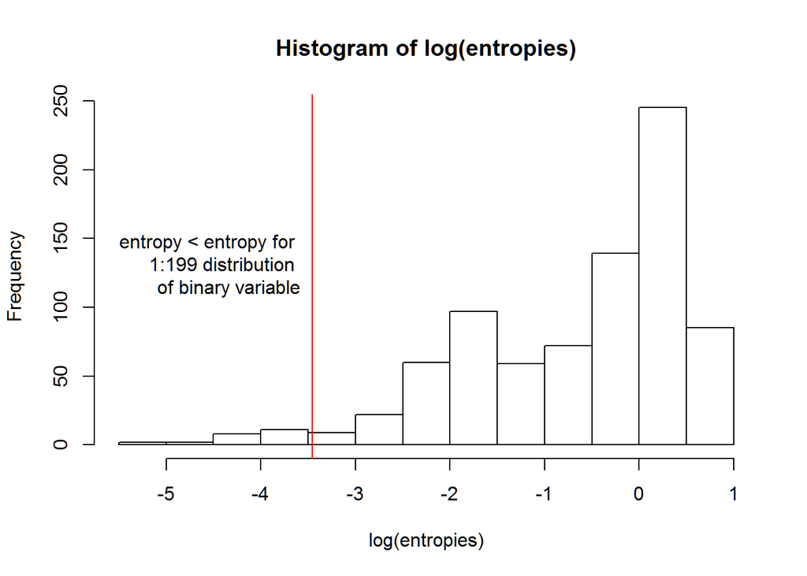

```r
entropies = c()
for(v in (MBQ+1):ncol(X_scaled)) {
  if (length(unique(X_scaled[,v])) > 10) {
    d = hist(X_scaled[,v],plot = F)$counts
  } else {
      d = table(X_scaled[,v])
  }
  entropies = c(entropies,entropy(d))
}

hist(log(entropies))
abline(v= log(entropy(c(1,199))),col = "red")
text(log(entropy(c(1,199))),par("usr")[4]/2,
     "entropy < entropy for \n 1:199 distribution \n of binary variable",
    pos = 2)
```

```r
# remove interactions with low entropy or no variation
rm_interactions = which(entropies < entropy(c(1,199)))

X_scaled = X_scaled[,-(rm_interactions+MBQ)]
interactions = interactions[,-rm_interactions]
N_interactions = ncol(rm_interactions)
```

We removed 26 interactions due to low entropy.

Now we are checking correlations with interaction variables and remove those that have a correlation > .9 with other non-interaction variables.

```r
cm = cor(X_scaled)
diag(cm) = 0
cm = abs(cm)

# identify interaction terms highly correlated with basic variables
rm_interactions = c()
for (k in (MBQ+1):ncol(cm)) {
  if(max(cm[1:MBQ,k]) > .9)
    rm_interactions = c(rm_interactions,k)
}

X_scaled = X_scaled[,-(rm_interactions+MBQ)]
interactions = interactions[,-rm_interactions]
N_interactions = ncol(N_interactions)
```

We removed 56 interactions due to high correlations with basic variables.

### Prepare imputation in Stan model

To prepare fast imputation in the Stan model, we also generate information about which interactions need to be re-calculated after imputation in Stan. In the same section, we also generate indices for missing data.

```r
has_missing = which(rowSums(is.na(preX)) > 0)
missing_interactions = matrix(0,
                          nrow = length(has_missing),
                          ncol = ncol(interactions))
j = 1
miss_row = c()
miss_col = c()
for (k in has_missing) {
  missing_vars = which(is.na(preX[k,]))
  mi = sort(c(which(interactions[1,] %in% missing_vars),
              which(interactions[2,] %in% missing_vars)))
  missing_interactions[j,1:length(mi)] = mi

  miss_row = c(miss_row,
               rep(k,length(missing_vars)))
  miss_col = c(miss_col,
               missing_vars)

  j = j+1
}
missing_interactions = missing_interactions[,colSums(missing_interactions) > 0]
N_missing_interactions = rowSums(missing_interactions > 0)
rm(j)

N_missing = length(miss_row)
N_has_missing = length(has_missing)
```

Finally, we can put the data for the Stan model together

```r
preX[is.na(preX)] = 1
standata = list(N = nrow(preX),
                M = ncol(preX),
                X = preX,
                y = y,
                N_missing = N_missing,
                miss_row = miss_row,
                miss_col = miss_col,
                M_quadratic = M_quadratic,
                scale_sd = scale_sd,
                scale_mu = scale_mu,
                transf_idx = range(transf_idx),
                m0 = 10,
                slab_scale = .5)
```

## The Stan model

This is a basic version of the model that does not include interactions yet. I’ll do this when I have some spare time.

One qualifier about imputation here: Because Stan does not work well with integer data, all variables that have an upper and lower bound are transformed to lie between 0 and 1, and imputed by applying a logit transform to a an unconstrained random imputation variable. The perfect way to solves this would be to marginalize over possible integer values, but this would get very complicated (and slower).

```r
cat(readLines("LRFH_pp_imp_q.stan"),sep = '\n')
```

```
## // the basic shrinkage model is from:
## // https://betanalpha.github.io/assets/case_studies/bayes_sparse_regression.html
## // GB added imputation procedure and generated quantities block
##
## data {
##   int<lower=1> N;              // Number of data
##   int<lower=1> M;              // Number of basic covariates
##   matrix[N, M] X;
##   real y[N];
##   int M_quadratic;             // number of variables tfor scaling and quadratic terms
##   real scale_sd[M+M_quadratic];  // stand deviations for scaling
##   real scale_mu[M+M_quadratic];  // means for scaling
##   int transf_idx[2];           // start and end idex of variables that need to be log-transformed
##   int N_missing;               // number of missing values
##   int miss_row[N_missing];     // row indices for missing values
##   int miss_col[N_missing];     // column indices for missing values
##   real m0;                     // Expected number of large slopes
##   real slab_scale;             // Scale for large slopes
##
## }
##
## // slab_scale = 5, slab_df = 25 -> 8 divergences
##
## transformed data {
##   real slab_scale2 = square(slab_scale);
##   real slab_df = 25;      // Effective degrees of freedom for large slopes
##   real half_slab_df = 0.5 * slab_df;
##   // number raw predictors + number squared predictors
##   //(all scaled predictors are also entered squared)
##   int MQ = M + M_quadratic;
##   // number raw predictors + number squared predictors + interactions
##   int MQI = MQ; // + N_interactions;
##   matrix[N, MQI] X_scaled;
##
##   X_scaled[,1:M] = X;
##   // scale to mean 0, sd 1 (after log transform, if required)
##   for (k in 1:M_quadratic) {
##     if (k >= transf_idx[1]) {
##       X_scaled[,k] = (log(X_scaled[,k])-scale_mu[k])/scale_sd[k];
##     } else {
```

[output cut: 66 more lines]

```
##   real y_hat[N];
##   // impute missing values and add quadratic term
##   for (i in 1:N_missing) {
##     Xi[miss_row[i],miss_col[i]] = miss_col[i] > M_quadratic ?
##                                   inv_logit(imputations[i]) :
##                                   imputations[i];
##     if (miss_col[i] <= M_quadratic) {
##        int i2 = M + miss_col[i];
##        Xi[miss_row[i], i2] = (Xi[miss_row[i], miss_col[i]]^2-scale_mu[i2]) /
##                               scale_sd[i2];
##     }
##   }
##
##   for (n in 1:N) y_hat[n] = normal_rng(dot_product(Xi[n,], beta) + alpha, sigma);
## }
```

compile the stan program

run the stan program (takes 1-2 hours with the full data set)

```r
options(mc.cores = 4)
sf = sampling(sm,
              data = standata,
              iter = 1000,
              pars = c("imputations","Xi"),
              control = list(adapt_delta = .95),
              include = FALSE)
save(sf,y,file = "sf.Rdata")
```

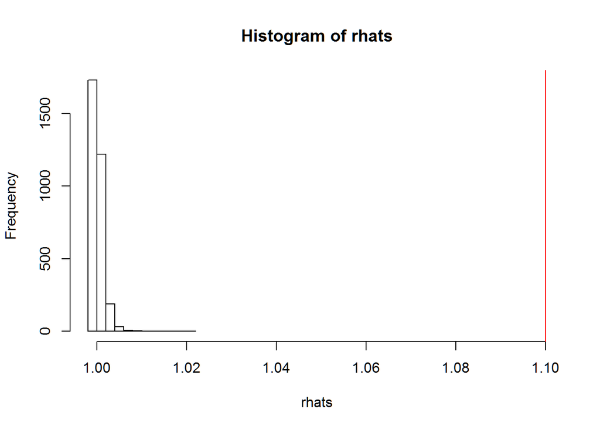

```r
load("sf.Rdata")
rhats = rhat(sf)
hist(rhats,
     xlim = c(min(1,min(rhats)),
              max(1.1,max(rhats))))
abline(v = 1.1, col = "red")
```

Plot correlation of observed and predicted s_ferritin levels.

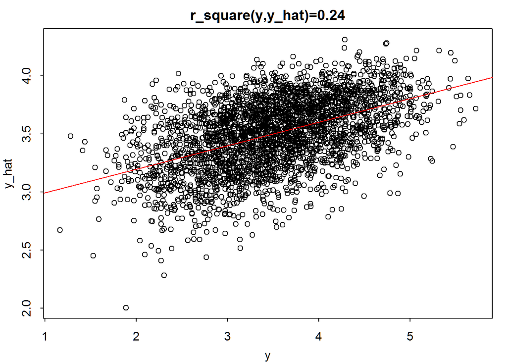

```r
y_hat = summary(sf,"y_hat")$summary[,"mean"]
par (mar=c(3,3,2,1), mgp=c(2,.7,0), tck=-.01)
plot(y,y_hat,
     main = paste0("r_square(y,y_hat)=",
                   round(cor(y,y_hat)^2,
                         digits = 2)))
abline(lm(y_hat~y), col = "red")
```

Lets look at the regression weights

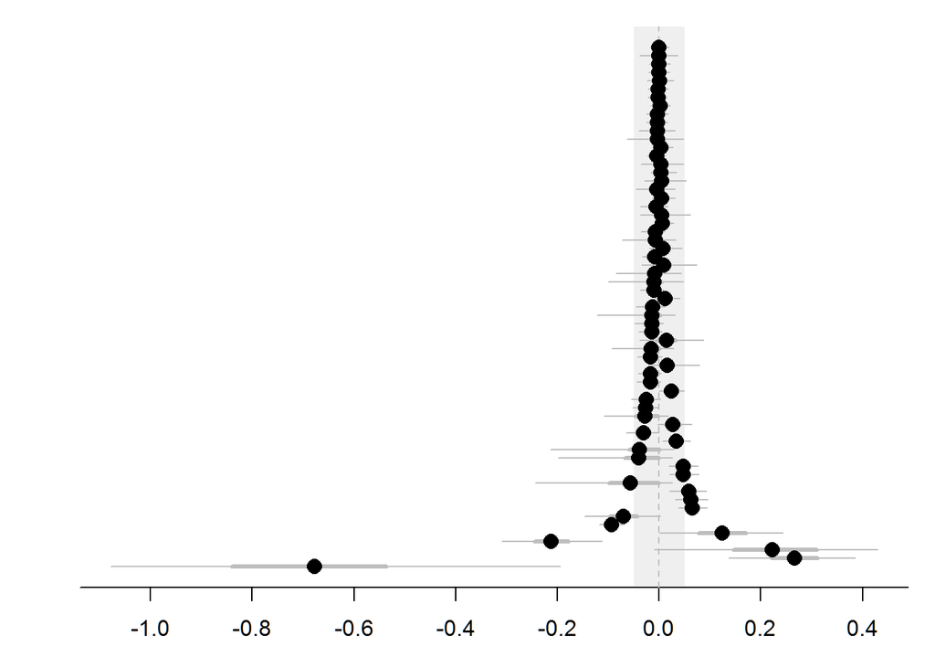

```r
plot_beta = function(b, pnames = T) {
  k = nrow(b)
  par(mar = c(3,3,1,1))
  xlim = range(c(b$`2.5%`,b$`97.5%`))
  plot(b$mean,
       1:k,
       xlim = xlim,
       ylab = "",
       yaxt = "n",
       xlab = "beta",
       pch = 16,
       bty = "n",
       xaxt = "n")
  axis(1,at = pretty(xlim,7))
  rect(.05,
       par("usr")[3],
       -.05,
       par("usr")[4],
       col = adjustcolor("grey", alpha = .25),
       border = NA)
  abline(v = 0, lty = 2, col = "grey")
  segments(x0 = b$`2.5%`,
           x1 = b$`97.5%`,
           y0 = 1:k,
           col = "grey")
  segments(x0 = b$`25%`,
           x1 = b$`75%`,
           y0 = 1:k,
           lwd = 2,
           col = "grey")
  segments(x0 = b$`25%`,
           x1 = b$`75%`,
           y0 = 1:k,
           lwd = 3,
           col = "grey")
  points(b$mean,1:k, pch = 16, cex = 1.5)
  if (pnames == T) {
    for(j in 1:k)
    text(x = min(b$mean),
         y = j,
         b$predictor[j],
         pos = 2,
         cex = .6)
  }
}

library(data.table)
b = c(colnames(preX), paste0(scale_vars,"2"))
beta = data.table(summary(sf,"beta")$summary)
beta[,predictor := b]
beta[,abs := -abs(mean)]
setkeyv(beta,"abs")

plot_beta(beta, pnames = F)
```

This are the 20 most important predictors. Note that variables that end in 2 are quadratic terms and variables that end in _b are binary variables derived from zero-inflated numeric variables.

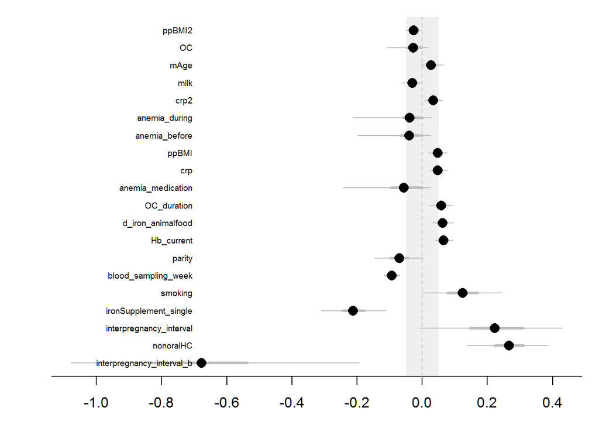

```r
plot_beta(beta[1:20,])
```

That’s it for now. We see that we get an $R^2$ that is OK but not great with this basic model. I can think of at least 4 things to do to approach a good prediction model:

- include interaction terms in the model
- add a variable selection step using the procedure described here https://arxiv.org/abs/1508.02502
- discuss out of sample prediction. In particular, we could estimate leave one out (LOO) cross validation, but this typically used in the context of model comparison, whereas we are more interested in variable selection.
- implement a more sophisticated imputation model, where ones uses a regression approach to infer imputation values